# Analysis Supplement Statistical Efficacy of Distance Matrix Anonymization

Coleman Harris

*All analyses were done using R version 3.5.1. Packages required for this document can be found in the code chunk below:*

```r
suppressPackageStartupMessages(require(ggmap))
suppressPackageStartupMessages(require(spgwr))
suppressPackageStartupMessages(require(gstat))
suppressPackageStartupMessages(require(raster))
suppressPackageStartupMessages(require(rms))
suppressPackageStartupMessages(require(Hmisc))
suppressPackageStartupMessages(require(GGally))
suppressPackageStartupMessages(require(knitr))
suppressPackageStartupMessages(require(kableExtra))
```

## Reading in and cleaning the data

The chunk below details some of the data cleaning, subsetting, and geocoding I did in order to make a clean, efficient dataset for this project.

```r
## NOT RUN:
#Allegheny Property Assessment Data
#Source: https://catalog.data.gov/dataset/allegheny-county-property-assessments
alle = readr::read_csv("data/Allegheny_Data/assessments-18.csv")

# subsetting on important features for geocoding
address = c("PROPERTYHOUSENUM",
            "PROPERTYADDRESS",
            "PROPERTYCITY",
            "PROPERTYSTATE",
            "PROPERTYZIP")

# some of the features are repetitive, not nec. useful for this project
# taking the most useful ones below
features = c("MUNICODE","SCHOOLCODE","NEIGHCODE","OWNERCODE","CLASS",
             "USECODE","LOTAREA","RECORDDATE","SALEDATE",
             "SALEPRICE","SALECODE","COUNTYBUILDING","COUNTYLAND",
             "COUNTYTOTAL","COUNTYEXEMPTBLDG","LOCALBUILDING","LOCALLAND",
             "LOCALTOTAL","FAIRMARKETBUILDING","FAIRMARKETLAND","FAIRMARKETTOTAL",
             "STYLE","STORIES","YEARBLT","EXTERIORFINISH",
             "ROOF","BASEMENT","GRADE","CONDITION",
             "CDU","TOTALROOMS","BEDROOMS","FULLBATHS",
             "HALFBATHS","HEATINGCOOLING","FIREPLACES",
             "BSMTGARAGE","FINISHEDLIVINGAREA","PREVSALEPRICE","PREVSALEPRICE2")
to_subset = c(address, features)
sub = alle[complete.cases(alle[,to_subset]),]

# taking random uniform subset of size 5000
# makes computations much simpler
set.seed(1717)
sampledPop = round(runif(5000,min=1,max=nrow(sub)))
samp = sub[sampledPop,]

#geocoding
# register_google("<API KEY HERE>")

# loop through values to geocode
# full Allegheny county set would take ~12hrs to geocode with google
# sample of 5000 takes ~45min
samp$lon = NA
samp$lat = NA

for(i in 1:nrow(samp)){
  addy = geocode(paste(samp[i,address],collapse=" "),
        output = "latlon",
        source = "google")
  samp[i,'lon'] = addy$lon
  samp[i,'lat'] = addy$lat
}

#save the dataset
saveRDS(samp,"AlleghenyPropertySample.Rds")
```

## Geocoding setup

Here, I import the cleaned Allegheny County property evaluation dataset, and also load the shapefiles for Allegheny County using the Database of Global Administrative Areas (GADM) data.

```r
samp = readRDS("AlleghenyCountySample.Rds")
us =getData('GADM',country="United States",level=2)
allegheny = subset(us,NAME_1=="Pennsylvania" & NAME_2 == 'Allegheny')
p4 = proj4string(allegheny)

# plot(allegheny)
# points(samp$lon,samp$lat,
#        col="dodgerblue",
#        pch=20)
```

## Lipschitz embedding method

```r
lipschitz_embedding <- function(d=20,k=10,dat){
  ## --- TRANSFORM TO LIPSCHITZ SPACE

  # number of observations
  N = nrow(dat)

  # matrix to hold embedded coords
  lipschitz.coords = matrix(0,nrow=N,ncol=d)

  for(i in 1:d){
    # random spatial sample of size k
    ## sample contained in england shapefile (e.g. map)
    ref.set = spsample(x=allegheny, #also could be newYork
                       n=k,
                       type = "random",
                       iter=+Inf)

    # find distances from each observation to random sample
    temp = spDists(x=SpatialPoints(dat[,c('lon','lat')],
                                   proj4string = CRS(p4)),
                   y=ref.set,
                   longlat = TRUE)

    # find minimum distance
    temp = apply(X = temp,
                 MARGIN = 1,
                 FUN = min)

    # store in matrix
    lipschitz.coords[,i] = temp
  }

  ## --- USE DISTANCE FOR KNN

  #calculate approximate distance function
  approx.dist = as.matrix(dist(lipschitz.coords,
                   method="maximum",
                   diag=TRUE,
                   upper=TRUE))

  list(lipschitz.coords,approx.dist)
}
```

## Fitting a simple OLS model

Since this is essentially a toy example for the problem at hand, I wanted to consider a simple model to implement in the GWR simulations. Since GWR is just a locally-weight linear regression, I ran and explored some simple model-building techniques using Frank Harrel’s `rms` package.

```r
samp$GRADE = factor(samp$GRADE,
                    levels = c("X+","X","X-",
                               "A+","A","A-",
                               "B+","B","B-",
                               "C+","C","C-",
                               "D+","D","D-"))

vars = c("CLASS","LOTAREA",
         "SALEPRICE",
         "STYLE","STORIES","YEARBLT","EXTERIORFINISH",
         "ROOF","BASEMENT","GRADE","CONDITION",
         "CDU","TOTALROOMS","BEDROOMS","FULLBATHS",
         "HALFBATHS","HEATINGCOOLING","FIREPLACES",
         "BSMTGARAGE","FINISHEDLIVINGAREA"
         ,"PREVSALEPRICE","PREVSALEPRICE2"
         )

form = as.formula(paste0("COUNTYTOTAL~",
                         paste(vars,collapse=" + ")))
mod1 = ols(form,data=samp)
dropped = fastbw(mod1)
# form2 = as.formula(paste0("COUNTYTOTAL~",
#                          paste(dropped$names.kept[-c(1,2,7,8,9,10)],collapse=" + ")))
# form.withGrade = as.formula(paste0("COUNTYTOTAL~",
#                          paste(dropped$names.kept[-c(1,2,4,6,8)],collapse=" + ")))
form.withoutGrade = as.formula(paste0("COUNTYTOTAL~",
                         paste(dropped$names.kept[-c(1,2,4,5,6,8)],collapse=" + ")))
vals.withoutGrade = dropped$names.kept[-c(1,2,4,5,6,8)]


# ols(form.withGrade, data=samp) # adj r2 = .847
# ols(form.withoutGrade, data=samp) #adj r2 = .763
```

## Calculating the betas

Below is the meat of the GWR process, which is done in lieu of the pre-programmed models in the `spgwr` package. The work done in that package was particularly helpful, since source code and functions were used to develop the following code. Specifically, the `gwr()` function in the `spgwr` did not allow for as much flexibility as desired for implementing the weights based on distance, so the source code calculations in `gwr()` were used instead. The same approach was taken for calculating the quasi-global $R^2$ from the `gwr()` model, which is essentially the mean $R^2$ over all points.

```r
#reproducibility
set.seed(1717)

#subset for less computation
vals = round(runif(100,0,5000))

#vals = 1:5000 #all data (full sample)

#scale and center, subset for columns of interest
clean_samp = as.matrix(samp[,c("COUNTYTOTAL",
                               vals.withoutGrade,"lon","lat")]) %>% scale()
cs1 = data.frame(clean_samp)
cs1 = cs1[vals,]

#calculate bandwidth for later W matrix calculations
# bandw = gwr.sel(form.withoutGrade,
#                 data=cs1,
#                 coords=cbind(cs1$lon,cs1$lat),
#                 longlat=TRUE)
bandw = 319.201408722481 #selected using full sample dataset above

#get orig. distances[o = orig.], use to calculate bisquare weights
oSamp = clean_samp
oDist = spDists(SpatialPoints(oSamp[,c('lon','lat')]))
w1 = gwr.bisquare(oDist^2,d=bandw)

#get lipschitz distances[l = lipschitz], use to calculate bisquare weights
lSamp = lipschitz_embedding(d=20,k=5,clean_samp)
lDist = lSamp[[2]]
w2 = gwr.bisquare(lDist^2,d=bandw)

#data structures to hold results from loop below
oBetaCoef = matrix(NA,
                  ncol=ncol(clean_samp[,2:7])+1,
                  nrow= nrow(w1))
oR2 = numeric(nrow(w1))
oR2.a = numeric(nrow(w1))

lBetaCoef = matrix(NA,
                  ncol=ncol(clean_samp[,2:7])+1,
                  nrow = nrow(w1))
lR2 = numeric(nrow(w1))
lR2.a = numeric(nrow(w1))

#calculate all betas and R2 for every location/model
for(i in 1:nrow(w1)){ #fit models and get coef for both iterations
  #--original data

  #fit locally weighted linear model
  oMod_i = lm(form.withoutGrade,
              weights=w1[i,],
              data=data.frame(clean_samp))
  oBetaCoef[i,] = coefficients(oMod_i) #get coef.

  oSumm = summary(oMod_i) #get summ.
  oR2[i] = oSumm$r.squared #get R2
  oR2.a[i] = oSumm$adj.r.squared #get adj. R2

  #--lipschitz data

  #fit locally weighted linear model, using Lipschitz distance mat
  lMod_i = lm(form.withoutGrade,
              weights=w2[i,],
              data=data.frame(clean_samp))
  lBetaCoef[i,] = coefficients(lMod_i) #get coef.

  lSumm = summary(lMod_i) #get summ.
  lR2[i] = lSumm$r.squared # get R2
  lR2.a[i] = lSumm$adj.r.squared #get adj. R2

  #if(i%%100==0){print(i)}
}

#calculate quasi-global (mean) R2
oQuasiR2 = mean(oR2)
oQuasiR2.a = mean(oR2.a)

lQuasiR2 = mean(lR2)
lQuasiR2.a = mean(lR2.a)

saveRDS(object = oBetaCoef,file = "oBetaCoef.Rds")
saveRDS(object = lBetaCoef,file = "lBetaCoef.Rds")

vals.R2 = rbind(cbind(oQuasiR2,oQuasiR2.a),
                cbind(lQuasiR2,lQuasiR2.a))
colnames(vals.R2) = c("$R^2$","Adj. $R^2$")
rownames(vals.R2) = c("Original","Lipschitz")
saveRDS(object = vals.R2,file="R2values.Rds")
```

## Graphical summaries

### Data setup

```r
oBetaCoef = readRDS("oBetaCoef.Rds")
lBetaCoef = readRDS("lBetaCoef.Rds")

lBetaCoef.df = data.frame(lBetaCoef)
oBetaCoef.df = data.frame(oBetaCoef)
colnames(lBetaCoef.df) = colnames(oBetaCoef.df) = c("Intercept",
                                                    "Sale Price",
                                                    "Total Rooms",
                                                    "Half Baths",
                                                    "Fireplaces",
                                                    "Finished Living Area",
                                                    "Previous Sale Price")

getScalePlot = function(plot_var){
  plot_dat = data.frame(rbind(cbind("Original",oBetaCoef.df[,plot_var]),
                              cbind("Lipschitz",lBetaCoef.df[,plot_var])))
  colnames(plot_dat) = c("Data","Values")
  plot_dat$Values = as.double(as.character(plot_dat$Values))

  ggplot(plot_dat, aes(x=Values,color=Data,fill=Data)) +
    geom_density(aes(y=..scaled..),alpha=0.5) +
    ylab("Scaled Density") +
    scale_color_manual(values = c("darkorange","darkgreen")) +
    scale_fill_manual(values = c("darkorange","darkgreen")) +
    ggtitle(paste0("Density of coefficient estimates for '",plot_var,"' \nby data-generating method"))
}
```

### Intercept

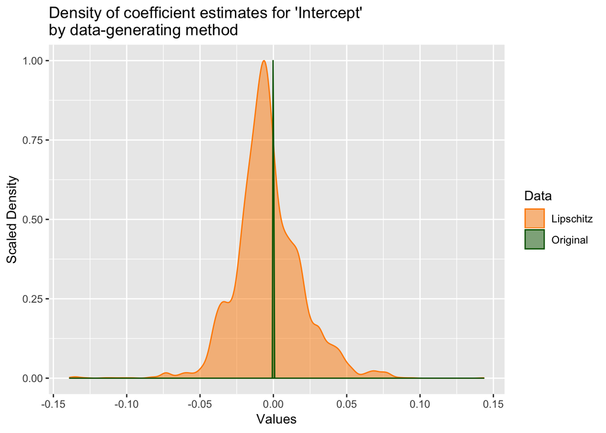

```r
p1 = getScalePlot("Intercept")
p1
```

```r
# ggsave("ggplots/intercept.png")
```

### Sale Price

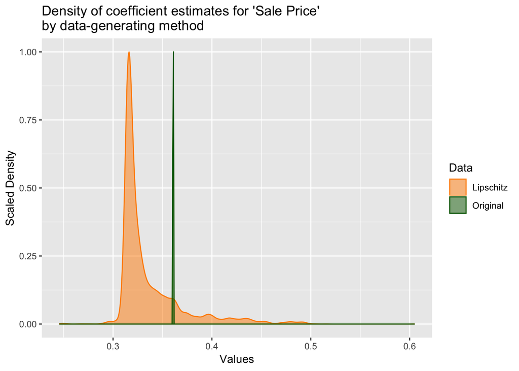

```r
p2 = getScalePlot("Sale Price")
p2
```

```r
# ggsave("ggplots/saleprice.png")
```

### Total Rooms

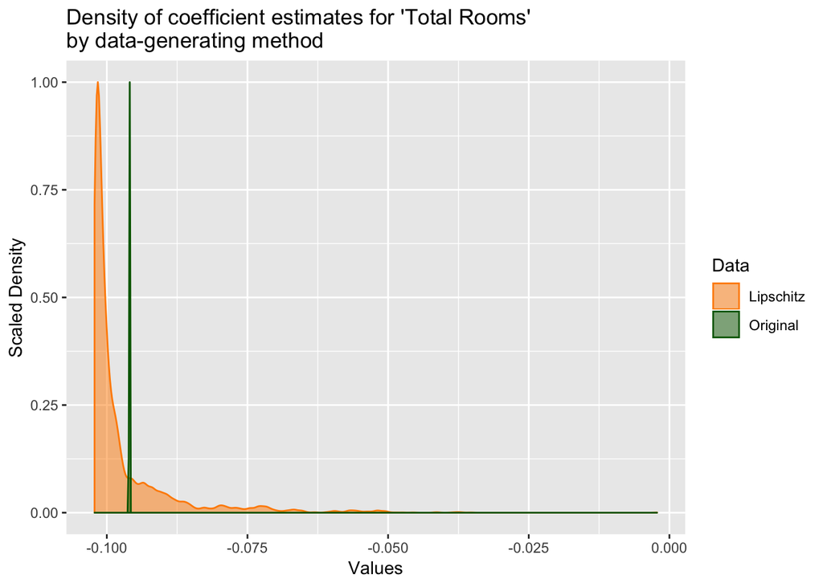

```r
p3 = getScalePlot("Total Rooms")
p3
```

```r
#ggsave("ggplots/totalrooms.png")
```

### Half Baths

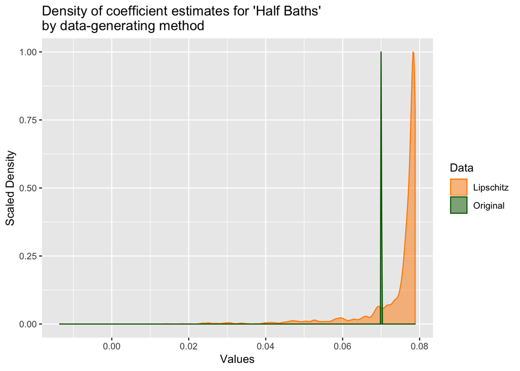

```r
p4 = getScalePlot("Half Baths")
p4
```

```r
# ggsave("ggplots/halfbaths.png")
```

### Fireplaces

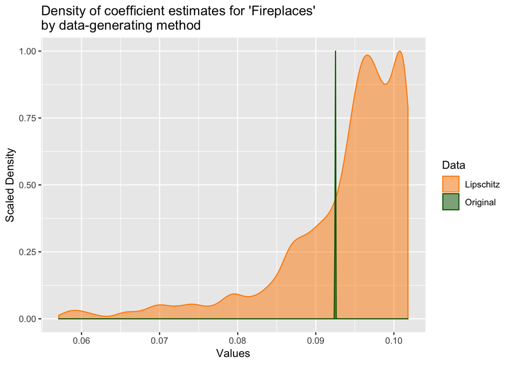

```r
p5 = getScalePlot("Fireplaces")
p5
```

```r
# ggsave("ggplots/fireplaces.png")
```

### Finished Living Area

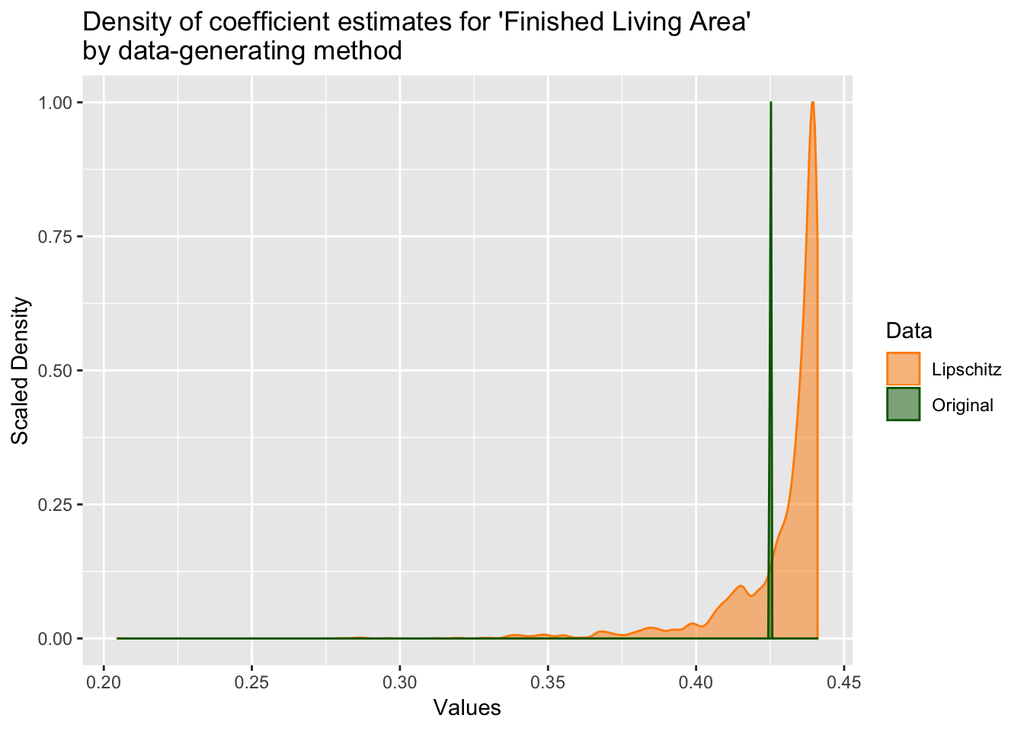

```r
p6 = getScalePlot("Finished Living Area")
p6
```

```r
# ggsave("ggplots/finishedliving.png")
```

### Previous Sale Price

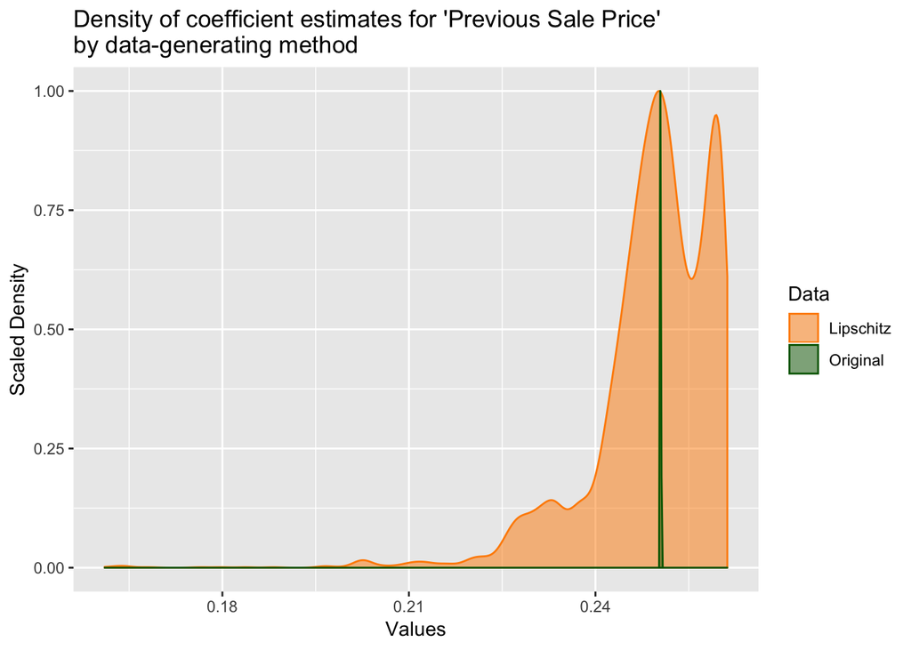

```r
p7 = getScalePlot("Previous Sale Price")
p7
```

```r
# ggsave("ggplots/prevsaleprice.png")
```

## Comparing $R^2$

```r
R2vals = readRDS("R2values.Rds")
kable(R2vals %>% round(4),caption="Table 2: Comparison of $R^2$ by data-generating method") %>%
  kable_styling(full_width = FALSE)
```

Table 2: Comparison of $R^2$ by data-generating method

|  | $R^2$ | Adj. $R^2$ |
| --- | --- | --- |
| Original | 0.7674 | 0.7671 |
| Lipschitz | 0.7438 | 0.7435 |

## Comparing Global Coefficients

Model:
$$\begin{align*}
\texttt{County Total} &= \hat\beta_0 + \hat\beta_1 (\texttt{Sale Price}) + \hat\beta_2 (\texttt{Total Rooms}) +\hat\beta_3 (\texttt{Half Baths})\\ &+\hat\beta_4 (\texttt{Fireplaces}) + \hat\beta_5 (\texttt{Finished Living Area}) + \hat\beta_6 (\texttt{Prev. Sale Price})
\end{align*}$$

```r
out.coef = rbind(colMeans(oBetaCoef.df),
                 colMeans(lBetaCoef.df))
rownames(out.coef) = c("Original","Lipschitz")

kable(out.coef %>% round(3),caption="Table 1: Comparison of coefficients by data-generating method") %>%
  kable_styling(full_width=FALSE)
```

Table 1: Comparison of coefficients by data-generating method

|  | Intercept | Sale Price | Total Rooms | Half Baths | Fireplaces | Finished Living Area | Previous Sale Price |
| --- | --- | --- | --- | --- | --- | --- | --- |
| Original | 0.000 | 0.361 | -0.096 | 0.070 | 0.093 | 0.425 | 0.250 |
| Lipschitz | -0.003 | 0.335 | -0.097 | 0.074 | 0.094 | 0.429 | 0.249 |